# PA1_template.Rmd

srngit

Friday, November 12, 2014

### Loading and Reading the data

First step is to load the data given. Please note that the GitHub repository also contains the dataset for the assignment so you do not have to download the data separately.

Following code reads the activity data from “activity.csv”. No transformation is done but the data is stored in two stored in two data frames.

```r
library(dplyr)
```

```r
activity <- read.csv("activity.csv")
initial_act <- activity
```

### Histogram of total steps and Mean, Median of total steps taken per day

The following code chunk creates a histogram of the total number of steps,taken on each day. activity data is summrized by date.

1. histogram

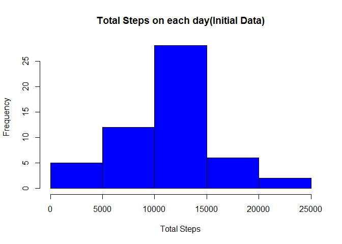

```r
total_steps <- summarise(group_by(activity,date),sum=sum(steps))
hist(total_steps$sum, main ="Total Steps on each day(Initial Data)",
     xlab ="Total Steps",col="blue")
```

```r
ts_mean   <- mean(total_steps$sum,na.rm=TRUE)
ts_median <- median(total_steps$sum,na.rm=TRUE)
```

### Average daily activity pattern

The following code makes a time series plot of the 5-minute interval (x-axis) and the average number of steps taken, averaged across all days (y-axis).

1. Time series

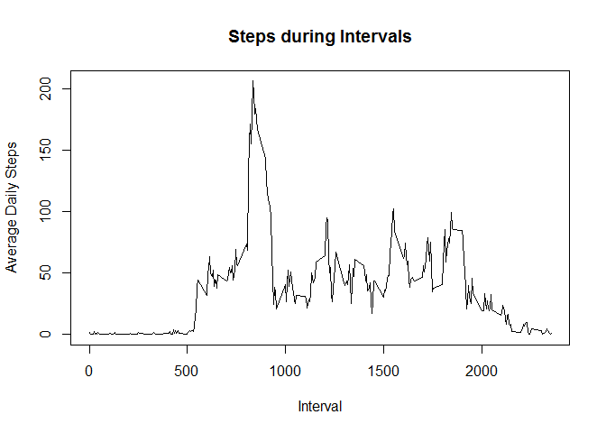

```r
daily_act <- summarise(group_by(activity,interval),average=mean(steps,na.rm=TRUE))
plot(daily_act$average ~ daily_act$interval, type="l", main = "Steps during Intervals", xlab="Interval", ylab ="Average Daily Steps")
```

2. The 5-minute interval with maximum number of steps:

```r
int <- daily_act[which(daily_act$average==max(daily_act$average)),1]
```

The 5-minute interval with maximum number of steps, on an average across all days is : 835

### Imputing missing values

1. Finding the number of missing values (NAs)

```r
total_NAs <- nrow(activity[activity$steps=="NA",])
```

There are NAs R in the data set are: 2304

### Strategy for filling all the missing values

2. Stratety: Replacing the missing [NA]value with the mean for that particular interval for entire period. This is achieved by matching of the two data sets namesly ‘activity’ and ‘daily_act’ by intervals and replacing the NAs in activity with the averages in the daily_act data set.

### New data set filled

3. The following code achieves the objective

```r
activity$steps[is.na(activity$steps)] <- daily_act$average[match(activity$interval[is.na(activity$steps)],daily_act$interval)]
```

### Histogram, mean and mean of the filled data set

4. 1. Histogram on filled data

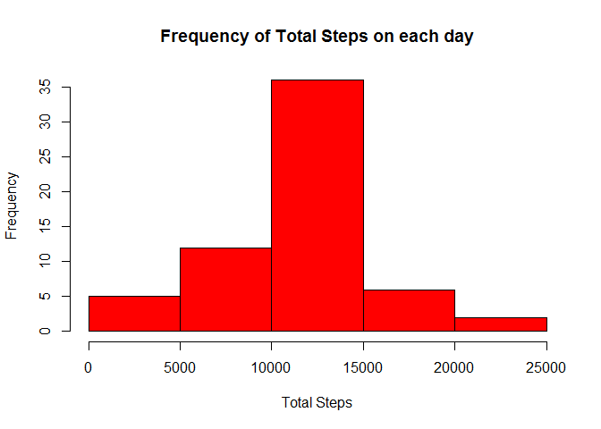

```r
fill_total_steps <- summarise(group_by(activity,date),sum=sum(steps))
hist(fill_total_steps$sum, main ="Frequency of Total Steps on each day",
     xlab ="Total Steps",col="red")
```

```r
fmean   <- mean(fill_total_steps$sum,na.rm=TRUE)
fmedian <- median(fill_total_steps$sum,na.rm=TRUE)
```

## Activity Patterns on Weekdays and Weekends

The activity levels are summarised by weekdays and weekends, using the following code:

```r
library(data.table)
```

```r
newData <- data.table(activity)
newData <- newData[ ,day:= as.factor(weekdays(as.Date(date),abbreviate =TRUE))]
levels(newData$day) <- c("weekday","weekday","weekend","weekend","weekday","weekday","weekday")
week_activity <- summarise(group_by(newData,interval,day),avg_steps =mean(steps))
```

## Panel plot depicting weekday and weekend patterns

```r
library(lattice)
```

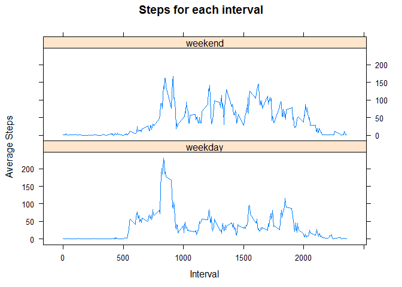

```r
xyplot(avg_steps ~ interval | day, data = week_activity, type="l",layout = c(1, 2), main="Steps for each interval", xlab ="Interval", ylab="Average Steps")
```